# SESI 4

### Broadcasting

Broadcasting adalah mekanisme yang memungkinkan harusNumPy melakukan operasi pada array dengan bentuk berbeda. Dimensi array harus kompatinel, misalnya jika dimensi kedua array sama atau salah satunya adalah 1. Jika dimensinya tidak kompatibel, maka akan mendapatkan balue arror.

```python
data + 10
```

```
array([11, 12])
```

```python
data * 10
```

```
array([10, 20])
```

```python
array_example.max()
```

```
7
```

```python
array_example.min()
```

```
0
```

```python
array_example.sum()
```

```
84
```

```python
A = np.empty((3,3))
A
```

```
array([[6.23042070e-307, 4.67296746e-307, 1.69121096e-306],
       [6.23058707e-307, 2.22526399e-307, 6.23053614e-307],
       [7.56592338e-307, 9.34588061e-307, 3.62651150e-317]])
```

```python
A = np.array([[0.45, 0.17, 0.34, 0.55],
              [0.54, 0.051, 0.40, 0.556],
              [0.127, 0.824, 0.265, 0.569]])
A
```

```
array([[0.45 , 0.17 , 0.34 , 0.55 ],
       [0.54 , 0.051, 0.4  , 0.556],
       [0.127, 0.824, 0.265, 0.569]])
```

```python
A.min(axis=0)
```

```
array([0.127, 0.051, 0.265, 0.55 ])
```

```python
A.min(axis=1)
```

```
array([0.17 , 0.051, 0.127])
```

```python
print(A.max(axis=0))
print(A.max(axis=1))
```

```
[0.54  0.824 0.4   0.569]
[0.55  0.556 0.824]
```

### Matrices

```python
np.ones((3,2))
```

```
array([[1., 1.],
       [1., 1.],
       [1., 1.]])
```

```python
np.zeros((3,2))
```

```
array([[0., 0.],
       [0., 0.],
       [0., 0.]])
```

```python
np.random.random((3,2))
```

```
array([[0.52502368, 0.4753221 ],
       [0.98768026, 0.03408109],
       [0.34005374, 0.98697817]])
```

```python
data = np.array([[1,2], [3,4]])
data
```

```
array([[1, 2],
       [3, 4]])
```

```python
one = np.ones((2,2))
one
```

```
array([[1., 1.],
       [1., 1.]])
```

```python
print(data + one)
```

```
[[2. 3.]
 [4. 5.]]
```

```python
one_row = np.ones((1,2))
one_row
```

```
array([[1., 1.]])
```

```python
print(data + one_row)
```

```
[[2. 3.]
 [4. 5.]]
```

```python
b = np.array([1,2])
```

```python
print( data+ b)
```

```
[[2 4]
 [4 6]]
```

```python
a_1 = np.array([[1,2,3], [4,5,6]])
print(a_1)
print(a_1.shape)

a_2 = np.array([[7,8], [9,10], [11,12]])
print(a_2)
print(a_2.shape)
```

```
[[1 2 3]
 [4 5 6]]
(2, 3)
[[ 7  8]
 [ 9 10]
 [11 12]]
(3, 2)
```

```python
np.dot(a_1, a_2).shape
```

```
(2, 2)
```

```python
data = np.array([[1,2], [3,4], [5,6]])
data
```

```
array([[1, 2],
       [3, 4],
       [5, 6]])
```

```python
print(data[0])
```

```
[1 2]
```

```python
print(data[0,1])
```

```
2
```

```python
print(data[2,0])
```

```
5
```

```python
print(data[0:2])
```

```
[[1 2]
 [3 4]]
```

```python
print(data[1:])
```

```
[[3 4]
 [5 6]]
```

```python
print(data[:,1])
```

```
[2 4 6]
```

### Matrix Agregation

```python
print(data)
```

```
[[1 2]
 [3 4]
 [5 6]]
```

```python
print(data.max())
print(data.min())
print(data.sum())
```

```
6
1
21
```

```python
print(data.max(axis=0))
print(data.max(axis=1))
```

```
[5 6]
[2 4 6]
```

### Transposing and Reshaping

Array NumPy memiliki properti yang disebut T untuk mendapatkan transpos dari sebuah matriks.

```python
print(data)
```

```
[[1 2]
 [3 4]
 [5 6]]
```

```python
print(data.T)
```

```
[[1 3 5]
 [2 4 6]]
```

```python
data_col = np.array([[1,2,3,4,5,6]]).T
print(data_col)
```

```
[[1]
 [2]
 [3]
 [4]
 [5]
 [6]]
```

```python
data_col.reshape(2,3)
```

```
array([[1, 2, 3],
       [4, 5, 6]])
```

```python
data_col.reshape(3,2)
```

```
array([[1, 2],
       [3, 4],
       [5, 6]])
```

```python
arr = np.arange(6).reshape((2,3))
arr
```

```
array([[0, 1, 2],
       [3, 4, 5]])
```

### N-Dimensional Array

```python
ndarr = np.array([
    [
        [1,2],
        [3,4]
    ],[
        [5,6],
        [7,8]
    ]
])
```

```python
ndarr.shape
```

```
(2, 2, 2)
```

```python
print(np.ones((4,3,2)))
```

```
[[[1. 1.]
  [1. 1.]
  [1. 1.]]

 [[1. 1.]
  [1. 1.]
  [1. 1.]]

 [[1. 1.]
  [1. 1.]
  [1. 1.]]

 [[1. 1.]
  [1. 1.]
  [1. 1.]]]
```

```python
print(np.zeros((4,3,2)))
```

```
[[[0. 0.]
  [0. 0.]
  [0. 0.]]

 [[0. 0.]
  [0. 0.]
  [0. 0.]]

 [[0. 0.]
  [0. 0.]
  [0. 0.]]

 [[0. 0.]
  [0. 0.]
  [0. 0.]]]
```

```python
print(np.random.random((4,3,2)))
```

```
[[[0.47550837 0.84768567]
  [0.57039093 0.13082712]
  [0.11827991 0.81315342]]

 [[0.45272898 0.51165429]
  [0.3304972  0.82129679]
  [0.64161419 0.19546299]]

 [[0.59665945 0.66992773]
  [0.65545348 0.03893928]
  [0.30948939 0.56692501]]

 [[0.60954929 0.89412699]
  [0.48944585 0.7008708 ]
  [0.58675802 0.38735292]]]
```

### Flatom N-Dimensional Array

Ada dua cara populer untuk meratakan array : .flatten() dan .ravel(). Perbedaan utama antara keduanya adalah bahwa array baru yang dibuat menggunak .ravel merupakan referensi ke array induk.

```python
arr = np.random.random((4,3,2))
```

```python
arr.shape
```

```
(4, 3, 2)
```

```python
arr.ndim
```

```
3
```

```python
arr_flatten = arr.flatten()
arr_flatten.ndim
```

```
1
```

### Working with Math Formulas

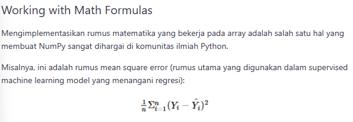

```python
error = (1/n) * np.sum(np.square(observed - prediction)
```

```
  Cell In[87], line 1
    error = (1/n) * np.sum(np.square(observed - prediction)
                                                           ^
SyntaxError: incomplete input
```

```python
arr = np. arange(1, 100, 3)
```

```python
print(arr.max())
```

```
97
```

```python
arr.mean()
```

```
49.0
```

```python
np.median(arr)
```

```
49.0
```

```python
np.log(arr)
```

```
array([0.        , 1.38629436, 1.94591015, 2.30258509, 2.56494936,
       2.77258872, 2.94443898, 3.09104245, 3.21887582, 3.33220451,
       3.4339872 , 3.52636052, 3.61091791, 3.68887945, 3.76120012,
       3.8286414 , 3.8918203 , 3.95124372, 4.00733319, 4.06044301,
       4.11087386, 4.15888308, 4.20469262, 4.24849524, 4.29045944,
       4.33073334, 4.36944785, 4.40671925, 4.44265126, 4.47733681,
       4.51085951, 4.54329478, 4.57471098])
```